# Interpretation of differential gene expression results

Author

Prof. Francesca Finotello

# Introduction

*Differential expression (DE) analysis* is a statistical approach in computational biology used to identify genes whose expression levels differ significantly between two or more groups of samples (e.g. diseased vs. healthy, treated vs. untreated). Statistical tests are applied to distinguish true biological differences from variability due to random noise.

DE analysis can be performed on newly generated datasets as well as on publicly available data. The [Gene Expression Omnibus (GEO)](https://www.ncbi.nlm.nih.gov/geo/) is a widely used repository that hosts a large collection of publicly available omics datasets. RNA sequencing (RNA-seq) data in GEO are typically provided as raw read counts and/or as normalized expression values (e.g., TPM or RPKM). Many GEO datasets are also connected to their native raw sequencing data (available as FASTQ files) via the [Sequence Read Archive (SRA)](https://www.ncbi.nlm.nih.gov/sra).

Other famous genomics and transcriptomics repositories are [ArrayExpress](https://www.ebi.ac.uk/arrayexpress/) and the [European Nucleotide Archive (ENA)](https://www.ebi.ac.uk/ena). Databases like [the Database of Genotypes and Phenotypes (dbGaP)](https://www.ncbi.nlm.nih.gov/gap/) and the [European Genome–phenome Archive (EGA)](https://ega-archive.org) provide controlled access to raw human genomics data, ensuring appropriate protection of sensitive information. Other famous omics repositories with a cancer focus the [The Cancer Genome Atlas (TCGA)](https://portal.gdc.cancer.gov) and the [International Cancer Genome Consortium (ICGC)](https://dcc.icgc.org).

# Exercises

## Exercise 1

For this exercise, we will consider an RNA-seq dataset that is available from the GEO with accession number GSE64655. This dataset was generated by [Hoek et al.](https://doi.org/10.1371/journal.pone.0118528) to study immune responses after influenza vaccination. Peripheral blood mononuclear cells (PBMC) and six purified cell types from two vaccinated donors were isolated prior to (day 0) and at days 1, 3, and 7 post vaccination for RNA-seq analysis.

From the whole dataset, comprising more than 50 RNA-seq samples, the following pre-vaccination (day 0) samples were selected for this exercise:

| Identifier | Sample name | Cell type |
| --- | --- | --- |
| GSM1576415 | HD30_T_0_SL27203 | T cells (day 0) |
| GSM1576443 | HD31_T_0_SL17287 | T cells (day 0) |
| GSM1576391 | HD30_B_0_SL27200 | B cells (day 0) |
| GSM1576419 | HD31_B_0_SL17288 | B cells (day 0) |

The edgeR package ([Robinson, McCarthy, and Smyth, 2010](https://doi.org/10.1093/bioinformatics/btp616)) for DE analysis of count data was used to contrast T-cell vs. B-cell samples. The table of results via DE analysis can be downloaded in the form of an Excel file (“Lymphocytes_DEGs.xlsx”) from the course OpenOLAT entry at [this link](https://lms.uibk.ac.at/auth/RepositoryEntry/5944246577/CourseNode/113086671488191). **Note**: you need to be logged in to access the file.

The table features on the rows all the genes considererd in the analysis, and on the columns:

- **Gene**: gene symbol/name according to [HGNC](https://www.genenames.org/).
- **logFC**: log2-fold-change. Interpreation: a logFC of 1 means that the level of expression of a gene is 2x in T cells compared to B cells; a logFC of -1 means 2x expression in B cells compared to T cells.
- **logCPM**: log-counts per millions (CPM), namely the average expression level of the gene in CPM across all samples, on a log2 scale. Interpretation: High logCPM means that a gene is highly expressed, low logCPM means that gene is lowly expressed.
- **F**: value of the *F statistic* from the quasi-likelihood F-test, that was used to identify differentially expressed (DE) genes in edgeR (note: other statistical tests are also available). It is used internally to compute the p-values. Interpretation: larger F values indicate a stronger evidence against the null hypothesis (i.e., gene not DE).
- **PValue**: p-value, quantifying the probability of observing such a difference in gene expression, for a specific gene, if there were truly no difference between groups (null hypothesis). Note: non corrected for multiple testing. Interpretation: small p-values indicate evidence of DE.
- **FDR**: p-value adjusted for multiple testing with Benjamini–Hochberg correcttion, controlling False Discovery Rate (FDR).

The genes on the rows are sorted by FDR (i.e., adjusted p-value) in ascending order, with the most significant genes on top, regardless of logFC.

We can download this table from the link above and use Excel (or a similar software) to explore the results.

We can start by identifying DE genes as those with FDR-corrected p-values <0.05 (i.e., 5% FDR threshold). For this, we can add a column in the file called “DE”, which reports a ‘1’ if the gene is DE (i.e., FDR<0.05), and ‘0’ otherwise. To do this, we can use the Excel built-in function “IF” which reads the data in the “FDR” column (column “F”) and processes it with the following formula: `IF(F<0,05;1;0)` (row indexes not reported, see figure below):

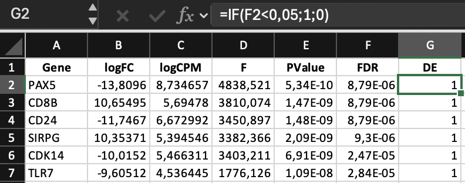

DE genes

We can now identify the genes that are *up-regulated* in T cells vs. B. cells, namely that have FDR<0.05 and logFC>0.  
For this, we can add a column in Excel called “UP”, which reports a ‘1’ in case the gene is up-regulated in T cells, and ‘0’ otherwise. We can use the Excel built-in function “IF” which takes the ‘1’ or ‘0’ value saved in the G column created at the previous step (answering the question: “is the gene DE?”) and the “logFC” column (B column) and processes it with the following formula: `G*(B>0)` (row indexes not reported, see figure below); only if the gene has both logFC>0 and DE=1, the multiplication in the formula results in a ‘1’ in the UP column for that gene:

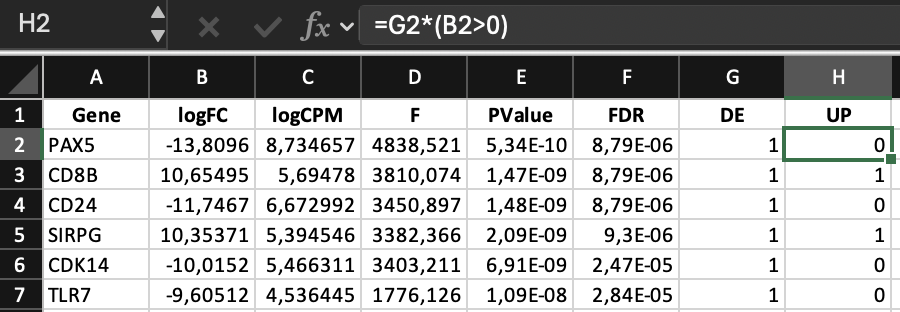

Up-regulated genes

❓ **Question:** How can we identify in another column only the genes that are *down-regulated* in T cells compared to B cells?

**Click to see the answer**

**Answer:**

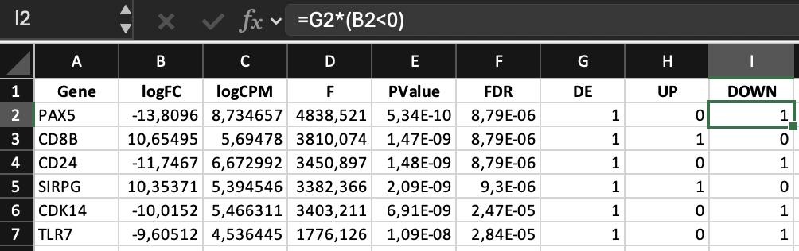

Down-regulated genes

❓ **Question:** How many total DE, up-regulated, and down-regulated genes did we find? *Hint:* use the “SUM” function of Excel to count the 1’s.

**Click to see the answer**

**Answer:**

- DE genes: 6,355;
- Up-regulated (i.e., higher expression in T cells): 3,094;
- Down-regulated (i.e., higher expression in B cells): 3,261.

❓ **Question:** How can we change these formulae to be stricter on logFC selection, i.e., to select fewer DE genes?

**Click to see the answer**

**Answer:**

We can, for instance, select only genes that have an absolute logFC greater than 1. This corresponds to using the formulae `G*(B>1)` and `G*(B<-1)`.

## Exercise 2

Making sense of DE results one gene at the time is unpractical, especially when having thousands of DE genes. A more practical alternative is to perform *fuctional analysis* to understand the functional meaning of gene-specific changes seen in our data by comparing them with sets of prior-knowledge genes known to participate in a biological process or function. The two main approaches for functional analysis of DE results are overrepresentation analysis (ORA) and gene-set enrichment analysis (GSEA). Popular web applications supporting these types of analyses are [DAVID](https://davidbioinformatics.nih.gov/), [g:Profiler](https://biit.cs.ut.ee/gprofiler/gost), and [Enrichr](https://maayanlab.cloud/Enrichr/), among many others.

In this exercise, we will use [Enrichr](https://maayanlab.cloud/Enrichr/) to functionally interpret up- and down-regulated genes identified from the dataset used in Exercise 1. Enrichr uses an approach similar to ORA: it consider in input a list of DE genes and identifies biological pathways, functions, or signatures that are statistically overrepresented in this list, using a Fisher’s exact test-based approach.

We start by first focusing only on on *up-regulated* genes. To do so, we can consider the “UP” column we created in the previous exercise, and leverage the Excel built-in “Filter” feature, which allows to display only rows meeting certain criteria. Hinst: you can use it to only display genes having a value of ‘1’ in the “UP” column.

After filtering/selecting only rows corresponding to up-regulated genes, we can manually select the corresponding gene-names, paste them in the Enrichr’s text box, and finally press “Submit”. Enrichr will then show the top gene sets enriched in your list of up-regulated genes, considering different types of prior knowledge.

❓ **Question:** How would you intepret the most enriched “Pathways”, “Onthologies”, and “Cell Types” (see top bar)? Do they align with your expectations for your list of DE genes up-regulated in T cells compared to B cells? *Hint*: have a look at the [Enrichr help page](https://maayanlab.cloud/Enrichr/help#basics) for more information about its output plots.

❓ **Question:** Run the same analysis on the down-regulated genes. What are your considerations for the Enrichr results obtained on this list of genes?

**Important note**: While Excel offers a convenient way to explore differential expression results, it can inadvertently corrupt gene names. By default, Excel may convert certain gene symbols into dates or floating-point numbers-for example, SEPT4 (septin 4) becomes 4-Sep, and MARCH1 (membrane associated ring-CH-type finger 1) becomes 1-Mar. A study by [(Ziemann, Eren, El-Osta, 2016)](https://link.springer.com/article/10.1186/s13059-016-1044-7) found that roughly 20% of papers with supplementary Excel gene lists contained such errors, and this issue appears to be increasing over time [(Lewis, 2021)](https://www.nature.com/articles/d41586-021-02211-4). For safer handling of gene lists and DE results, it is recommended to use programming languages such as [R](https://www.r-project.org/) or [Python](https://www.python.org/).

## Exercise X

Focusing on the Hoek dataset (GSE64655) used in the previous exercises, we want to focus on PBMC samples only, and compare post vaccination samples from day 7 with pre-vaccination ones (day 0). Specifically, we want to focus on these samples:

| Identifier | Sample name | Condition |
| --- | --- | --- |
| GSM1576411 | HD30_PMBC_0_SL27199 | PBMC, day 0 (pre-vaccination) |
| GSM1576439 | HD31_PBMC_0_SL17281 | PBMC, day 0 (pre-vaccination) |
| GSM1576414 | HD30_PBMC_7_SL27220 | PBMC, day 7 (post-vaccination) |
| GSM1576442 | HD31_PBMC_7_SL17305 | PBMC, day 7 (post-vaccination) |

Our dataset of interest (GSE64655) is available for GEO2R analysis at the following link: https://www.ncbi.nlm.nih.gov/geo/geo2r/?acc=GSE64655.

To create the two groups of interests to be compared in our DE analysis, i.e., “pre-vaccination” and “post-vaccination”, we need to click on “Define groups” under the “Samples” left tab. We can now enter the group names by typing “post” (for “post-vaccination”), and “pre” (for “pre-vaccination”). **Important**: it is key to specify the groups in this order, so the DE analysis is peformed looking at changes in the post-vaccination data compared to the pre-vaccination one (and not the other way around).

[figure not shown]

We can now click on the first sample to be assigned to a group of interest (“HD30_PBMC_7_SL27220”), and then on the “post” label, to finalize the assignment. And we do the same for the “HD31_PBMC_7_SL17305” sample.

[figure not shown]

We repeat the same action for the “HD30_PMBC_0_SL27199” and “HD31_PBMC_0_SL17281” samples, but assigning them to the “pre” group. Now we have two samples per condition.

[figure not shown]

- **Symbol**: gene symbol/name according to [HGNC](https://www.genenames.org/).
- **log2FoldChange**: log2-fold-change. Here, if the groups are specified in the right order (see **Note** above), a positive log2FoldChange indicates genes up-regulated post-vaccination, while a negative one indicates down-regulated ones.
- **pvalue**: p-value.
- **padj**: p-value adjusted for multiple testing. By default, Benjamini–Hochberg correction (FDR) is used, but other options can be specified before running the analysis.

❓ **Question:** What are the top 3 (according to “padj”) up-regulated genes post-vaccination and how do you interpret them?

❓ **Question:** What are the top 3 (according to “padj”) down-regulated genes post-vaccination and how do you interpret them?

❓ **Question:** Select DE genes with an adjusted p-value<0.05 and an absolute log2-fold-change larger than 1 and perform functional analysis with Enrichr. What are the functions/processes/cell types up-regulated/enriched post-vaccinations? And those down-regulated/depleted?